# Version control with `git`

Alexander Poon alex.poon@tn.gov

June 28, 2017

# What is `git` ?

From https://git-scm.com/:

> Git is a free and open source distributed version control system designed to handle everything from small to very large projects with speed and efficiency.

# What is ‘version control’?

Like track changes + a super save button.

With `git`, you can:

- See what your files look like at earlier save points
- See what’s changed since last save
- Revert to earlier version of saved files

# When should you use `git`?

- You want to track changes to your code over time
- You want a backup of your code
- You want others to see your code
- You want others to use your code

# Setup

Download `git` at:

Windows: https://git-scm.com/download/win  
macOS: https://git-scm.com/download/mac

Sign up for an account at https://github.com/

# The shell

To use `git`, we’re going to work in the shell.

“Shell” ≈ “bash” ≈ “Command Line” ≈ “Terminal” ≈ “tty” ≈ “Console”

= A way to tell your computer to do things with commands, rather than clicks.

[See https://unix.stackexchange.com/questions/4126/what-is-the-exact-difference-between-a-terminal-a-shell-a-tty-and-a-con for the technical details]

# The shell

[figure not shown]

# Working directory

At all times, you are in a **working directory**. `pwd` returns your current working directory:

`$ pwd`

`/Users/alexanderpoon`

[This is your home directory, also denoted by `~`]

# What’s in my working directory?

`ls` lists what’s in your working directory:

`$ ls`

```
Applications/ Desktop/ Documents/ Downloads/ Dropbox/ Library/ Movies/
Music/ Pictures/ Public/
```

# Command Options

Shell commands have options that alter their behavior:

`$ ls -l`

```
drwx------ 7 alexanderpoon staff 238B May 22 12:52 Applications/
drwx------+ 13 alexanderpoon staff 442B Jun 23 11:17 Desktop/
drwx------+ 5 alexanderpoon staff 170B Mar 28 15:12 Documents/
drwx------+ 4 alexanderpoon staff 136B Jun 18 17:28 Downloads/
drwx------@ 10 alexanderpoon staff 340B Apr 28 14:43 Dropbox/
drwx------@ 71 alexanderpoon staff 2.4K Jun 13 14:11 Library/
drwx------+ 3 alexanderpoon staff 102B Aug 18 2014 Movies/
drwx------+ 7 alexanderpoon staff 238B Dec 14 2015 Music/
drwx------+ 7 alexanderpoon staff 238B Oct 4 2015 Pictures/
drwxr-xr-x+ 6 alexanderpoon staff 204B Jul 18 2016 Public/
```

# Documentation for shell commands

For shell commands, access documentation with `man` (useful for options):

`$ man <name of command>`

(in Git Bash `<name of command> --help`)

[Hit `q` to exit the documentation]

# Documentation for shell commands

`$ man ls`

[figure not shown]

# Create a folder

Git repositories live inside a folder. Create a folder with `mkdir`:

`$ mkdir Desktop/myFirstRepo`

# Navigating to another directory

Change your working directory with `cd`. Specify paths relative to your current working directory:

`$ cd Desktop/myFirstRepo`

or with an absolute path:

`$ cd /Users/alexanderpoon/Desktop/myFirstRepo`

# Summary of shell commands

- `pwd` - show working directory
- `cd` - change working directory
- `ls` - list contents of a directory
- `mkdir` - create a new folder
- `man` - documentation (macOS and Linux)
- `<name of command> --help` - documentation (Windows)

# Bonus

- ↑ - pull up prior commands
- `clear` - clear your window
- `cat` - print something
- `touch` - create a new file
- `rm` - delete a file
- `rmdir` - delete an empty folder
- `rm -rf` - delete a non-empty folder and its contents (use with caution!)
- `mv` - move a file
- `cp` - copy a file
- `~` - home directory (as in `cd ~`)
- `..` - parent directory (as in `cd ..`)

More here: https://gist.github.com/LeCoupa/122b12050f5fb267e75f

# `git`

# Configuring `git`

`$ git config --global user.name your_username` `$ git config --global user.email your_email`

Do this once, when starting to use `git` on a new computer.

# Commits

The fundamental `git` operation is the `commit`, which tells `git`: “remember what my files look like at this point”.

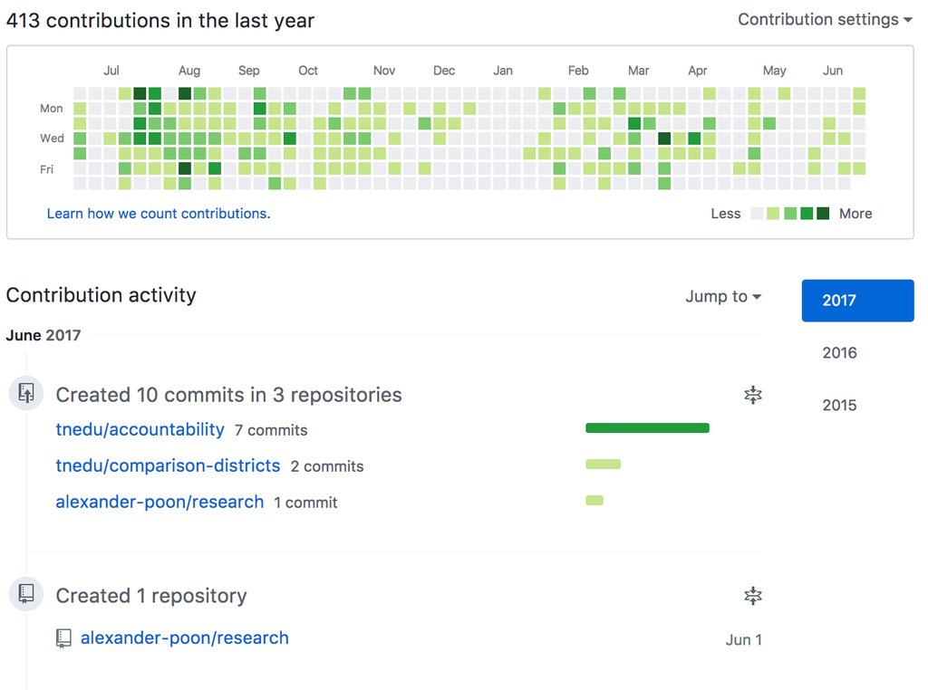

With `git`, you can:

- See what files look like at earlier commits
- See what’s changed since last commit
- Revert to version of saved files at prior commits

# Commits

Steps before committing:

1. Navigate to directory where you want to use version control
2. Initialize a `git` repository
3. Tell `git` which files to track

# Start using version control

Initialize a `git` repository with `git init`:

`$ git init`

```
Initialized empty Git repository in /Users/alexanderpoon/Desktop/
myFirstRepo/.git/
```

# Start using version control

[figure not shown]

# Start using version control

We need some files to work with version control:

`$ echo "# A new file" > first.txt`

- > is a pipe operator that passes the output of one command to a file

# Check status of your git repository

At any time, check the status of a `git` repository with `git status`:

`$ git status`

```
On branch master

Initial commit

Untracked files:
(use "git add <file>..." to include in what will be committed)

    first.txt
```

# Prepare a commit

Git doesn’t track anything by default. Tell it to start tracking files with `git add`:

`$ git add first.txt`

# Prepare a commit

Check the status again:

`$ git status`

```
On branch master

Initial commit

Changes to be committed:
(use "git rm --cached <file>..." to unstage)

new file:   first.txt
```

# First commit!

Now we’re ready to commit with `git commit`. Add flag `-m` with a message describing what we’re committing (mandatory):

`$ git commit -m 'my first commit'`

```
[master (root-commit) a8d0ec1] my first commit
1 file changed, 1 insertion(+)
create mode 100644 first.txt
```

# First commit!

Check status again:

`$ git status`

```
On branch master
nothing to commit, working tree clean
```

# More commits

Edit existing file:

`$ echo "# A new line" >> first.txt`

- >> is a pipe operator that appends the output of one command to a file

Add some more stuff:

`$ mkdir subfolder`  
`$ cd subfolder`  
`$ echo "# New file one" > one.txt`  
`$ echo "# New file two" > two.txt`  
`$ cd ..`

# More commits

Check status again:

```
On branch master
Changes not staged for commit:
(use "git add <file>..." to update what will be committed)
(use "git checkout -- <file>..." to discard changes in working directory)

    modified:   first.txt

Untracked files:
(use "git add <file>..." to include in what will be committed)

    subfolder/
```

# More commits

You can `git add` individual files:

`$ git add first.txt`

Or entire subfolders:

`$ git add subfolder/`

Or everything all at once:

`$ git add .`

[`$ git help add` to read documentation]

# A note on `git add`

- The first use of `git add` on a file tells git to start tracking that file
- Subsequent uses of `git add` tells `git` to reflect changes to that file in next commit

# More commits

Commit these changes:

`$ git status`

```
On branch master
Changes to be committed:
  (use "git reset HEAD <file>..." to unstage)

    modified:   first.txt
    new file:   subfolder/one.txt
    new file:   subfolder/two.txt
```

`$ git commit -m 'add subfolder'`

# Make one more change and commit

`$ echo "# Another new line" >> first.txt` `$ git add first.txt` `$ git commit -m 'really important update'`

# What do my prior commits look like?

View your commit history with `git log`:

`> git log`

```
commit ec19e8c7a0234474d5c06c9366f550f48b3ab547
Author: alexander-poon <alexander.poon@vanderbilt.edu>
Date:   Tue Jun 27 14:29:22 2017 -0500

    really important update

commit 6a7849789a03fa0324d690baa23bdd476a56e234
Author: alexander-poon <alexander.poon@vanderbilt.edu>
Date:   Tue Jun 27 14:29:22 2017 -0500

    add subfolder

commit 34a35301edc07d9e996364fedfaf5b085dc42f87
Author: alexander-poon <alexander.poon@vanderbilt.edu>
Date:   Tue Jun 27 14:29:22 2017 -0500

    my first commit
```

# Oops, I made a mistake

Undo a commit with `git revert`:

`$ git revert ec19e8c --no-edit`

This creates a new commit where the state of files will be that prior to the specified commit.

# Oops, I made a mistake

Check this is the case with `git log`:

`$ git log`

```
commit ef61aaeeda1a848815a49c23991758005683c8f0
Author: alexander-poon <alexander.poon@vanderbilt.edu>
Date:   Tue Jun 27 14:37:31 2017 -0500

    Revert "really important update"

    This reverts commit ec19e8c7a0234474d5c06c9366f550f48b3ab547.

commit ec19e8c7a0234474d5c06c9366f550f48b3ab547
Author: alexander-poon <alexander.poon@vanderbilt.edu>
Date:   Tue Jun 27 14:29:22 2017 -0500

    really important update

commit 6a7849789a03fa0324d690baa23bdd476a56e234
Author: alexander-poon <alexander.poon@vanderbilt.edu>
Date:   Tue Jun 27 14:29:22 2017 -0500

    add subfolder

commit 34a35301edc07d9e996364fedfaf5b085dc42f87
Author: alexander-poon <alexander.poon@vanderbilt.edu>
Date:   Tue Jun 27 14:29:22 2017 -0500

    my first commit
```

# Oops, I made a mistake

Check this is the case with `cat`:

`$ cat first.txt`

```
# A new file
# A new line
```

# Remote repositories

Everything we’ve done thus far is local to our machines. A lot of the power of `git` comes through publishing code with remote repositories on the internet.

# Remote repositories

[figure not shown]

# Remote repositories

Point your local repository to a remote repository on GitHub with `git remote add`:

`$ git remote add origin https://github.com/alexander` `-poon/myFirstRepo.git`

‘origin’ is a shorthand name for your remote repository (call it whatever you want)

# Remote repositories

Push changes to the remote repository with `git push`:

`$ git push origin master`

`origin` is the name of the remote repository that you specified with `git remote add`

# Remote repositories

[figure not shown]

# Remote repositories

Just like your local repository, your GitHub repository has your entire commit history. Github also provides:

- Ability to make a copy of any GitHub repository
- Issues and documentation of your code/projects

# Clean up

Delete this folder with:

`$ cd ..`  
`$ rm -rf myFirstRepo`

# Git workflow (First time around)

1. Create a local repository
2. Create files in repository
3. `git add` one or more files to start tracking changes
4. Add one or more `commit`s
5. Point local repository to remote repository
6. `push` to remote

# Git workflow (ongoing)

1. Modify files
2. `git add` one or more files to `commit`
3. Add one or more `commits`
4. `push` changes to remote

# References

- Learn the Command Line via Codecademy https://www.codecademy.com/learn/learn-the-command-line
- Official git documentation https://git-scm.com/book/en/v2